# CMPINF 2130 Summer 2022 - Week 03

### Trends per group

Include separate trends per category or Grouping value.

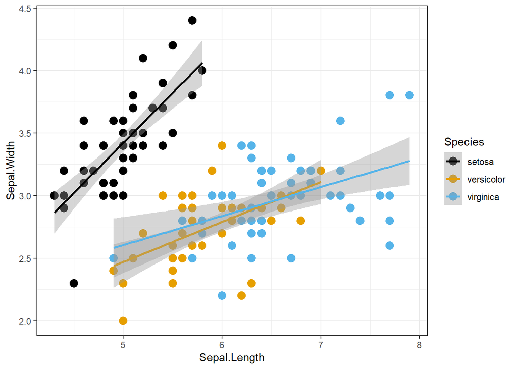

```r
iris %>%
  ggplot(mapping = aes(x = Sepal.Length, y = Sepal.Width)) +
  geom_point(mapping = aes(color = Species),
             size = 3.5) +
  geom_smooth(formula = y ~ x,
              method = lm,
              mapping = aes(color = Species)) +
  ggthemes::scale_color_colorblind() +
  theme_bw()
```

We can change the ribbon color by the `fill` aesthetic.

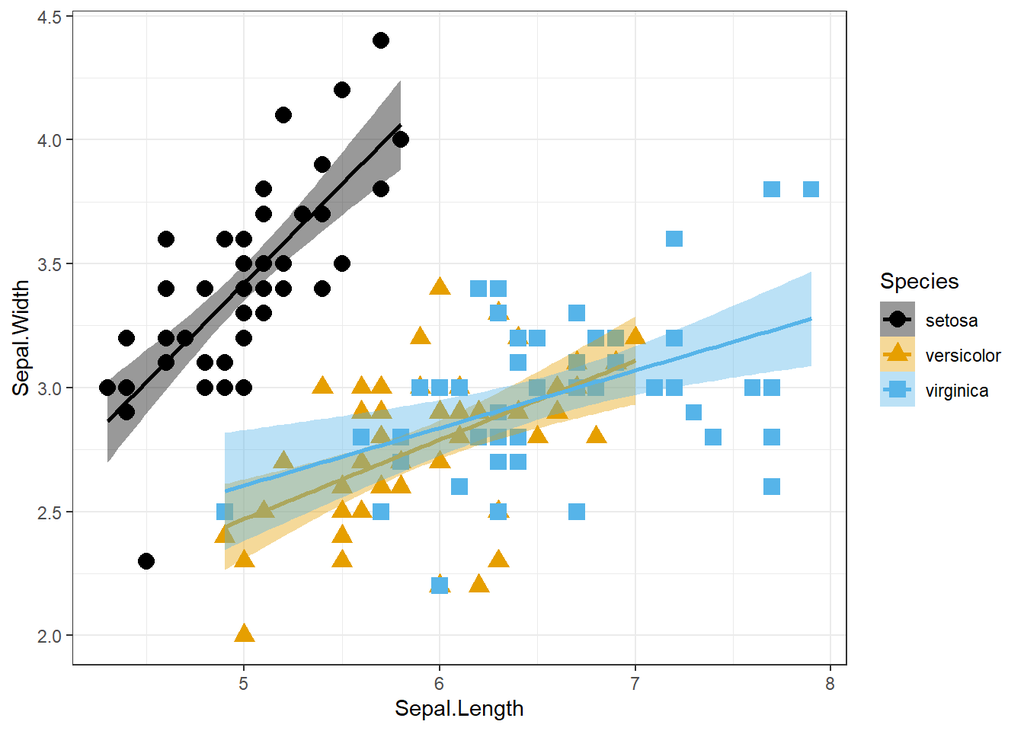

```r
iris %>%
  ggplot(mapping = aes(x = Sepal.Length, y = Sepal.Width)) +
  geom_point(mapping = aes(color = Species,
                           shape = Species),
             size = 3.5) +
  geom_smooth(formula = y ~ x,
              method = lm,
              mapping = aes(color = Species,
                            fill = Species)) +
  ggthemes::scale_color_colorblind() +
  ggthemes::scale_fill_colorblind() +
  theme_bw()
```

The linetype is like marker shape.

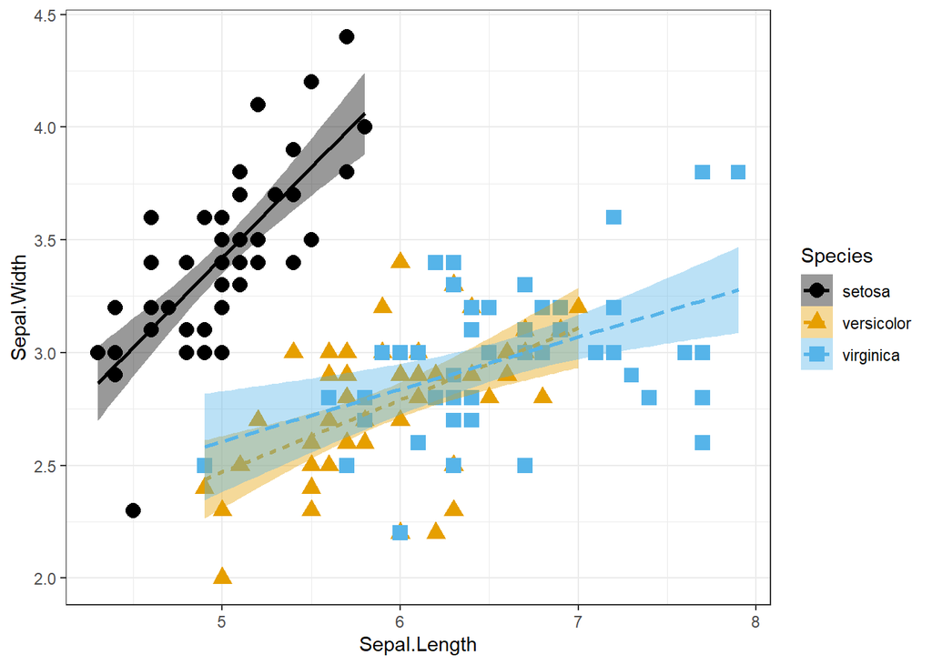

```r
iris %>%
  ggplot(mapping = aes(x = Sepal.Length, y = Sepal.Width)) +
  geom_point(mapping = aes(color = Species,
                           shape = Species),
             size = 3.5) +
  geom_smooth(formula = y ~ x,
              method = lm,
              mapping = aes(color = Species,
                            fill = Species,
                            linetype = Species)) +
  ggthemes::scale_color_colorblind() +
  ggthemes::scale_fill_colorblind() +
  theme_bw()
```

We can include the UNGROUPED linear trend in this figure.

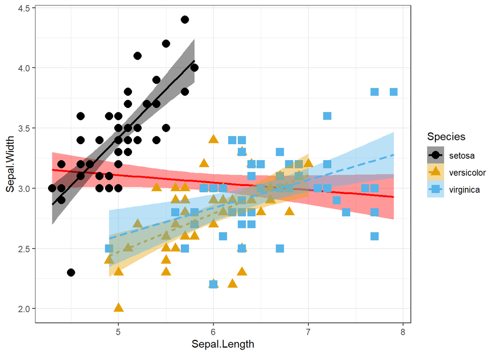

```r
iris %>%
  ggplot(mapping = aes(x = Sepal.Length, y = Sepal.Width)) +
  geom_smooth(formula = y ~ x,
              method = lm,
              color = 'red', fill = 'red') +
  geom_point(mapping = aes(color = Species,
                           shape = Species),
             size = 3.5) +
  geom_smooth(formula = y ~ x,
              method = lm,
              mapping = aes(color = Species,
                            fill = Species,
                            linetype = Species)) +
  ggthemes::scale_color_colorblind() +
  ggthemes::scale_fill_colorblind() +
  theme_bw()
```

Confidence intervals make plots busy…so we can turn them off.

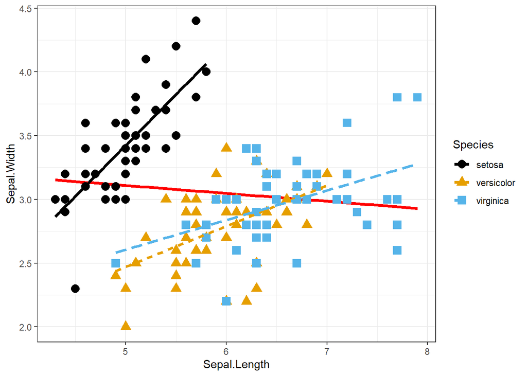

```r
iris %>%
  ggplot(mapping = aes(x = Sepal.Length, y = Sepal.Width)) +
  geom_smooth(formula = y ~ x,
              method = lm,
              color = 'red', fill = 'red',
              se = FALSE,
              size = 1.25) +
  geom_point(mapping = aes(color = Species,
                           shape = Species),
             size = 3.5) +
  geom_smooth(formula = y ~ x,
              method = lm,
              mapping = aes(color = Species,
                            fill = Species,
                            linetype = Species),
              se = FALSE,
              size = 1.25) +
  ggthemes::scale_color_colorblind() +
  ggthemes::scale_fill_colorblind() +
  theme_bw()
```

I **never** recommend showing a smoothing line WITHOUT markers.

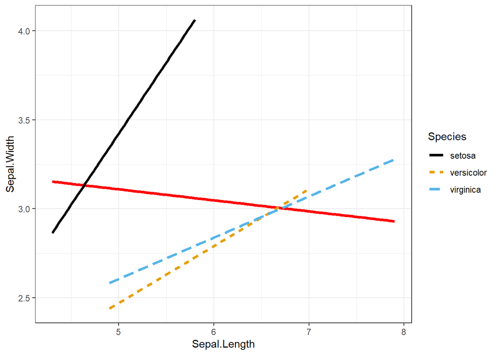

```r
iris %>%
  ggplot(mapping = aes(x = Sepal.Length, y = Sepal.Width)) +
  geom_smooth(formula = y ~ x,
              method = lm,
              color = 'red', fill = 'red',
              se = FALSE,
              size = 1.25) +
  # geom_point(mapping = aes(color = Species,
  #                          shape = Species),
  #            size = 3.5) +
  geom_smooth(formula = y ~ x,
              method = lm,
              mapping = aes(color = Species,
                            fill = Species,
                            linetype = Species),
              se = FALSE,
              size = 1.25) +
  ggthemes::scale_color_colorblind() +
  ggthemes::scale_fill_colorblind() +
  theme_bw()
```

### Continuous colors

We can have 3 variables on a scatter plot where the 3rd variable is continuous and we use color to show the values of that continuous variable.

```r
iris %>% summary()
```

```
##   Sepal.Length    Sepal.Width     Petal.Length    Petal.Width
##  Min.   :4.300   Min.   :2.000   Min.   :1.000   Min.   :0.100
##  1st Qu.:5.100   1st Qu.:2.800   1st Qu.:1.600   1st Qu.:0.300
##  Median :5.800   Median :3.000   Median :4.350   Median :1.300
##  Mean   :5.843   Mean   :3.057   Mean   :3.758   Mean   :1.199
##  3rd Qu.:6.400   3rd Qu.:3.300   3rd Qu.:5.100   3rd Qu.:1.800
##  Max.   :7.900   Max.   :4.400   Max.   :6.900   Max.   :2.500
##        Species
##  setosa    :50
##  versicolor:50
##  virginica :50
##
##
##
```

Color based on `Petal.Length`.

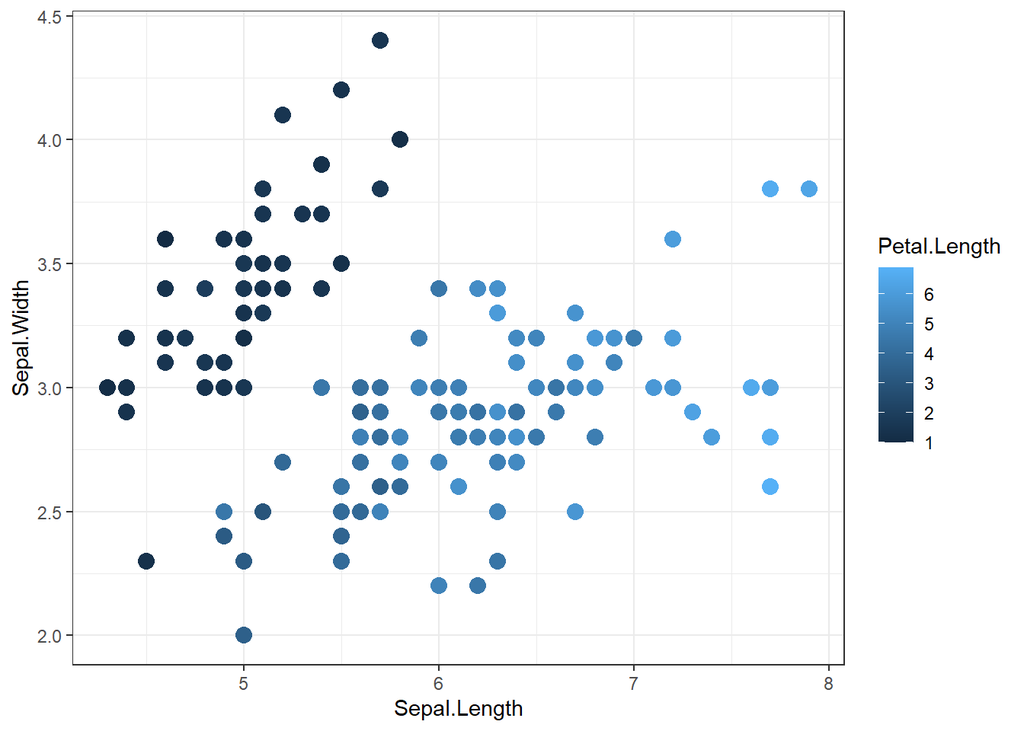

```r
iris %>%
  ggplot(mapping = aes(x = Sepal.Length, y = Sepal.Width)) +
  geom_point(mapping = aes(color = Petal.Length),
             size = 3.5) +
  theme_bw()
```

We can use the brewer library’s distiller function to create other continuous color palletes.

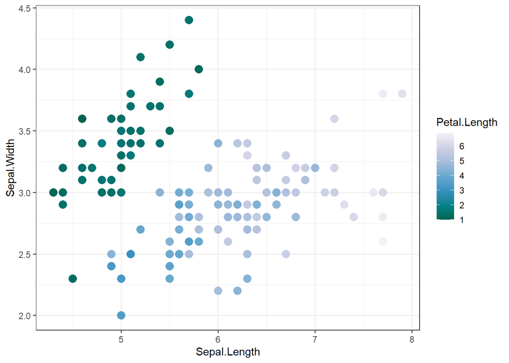

```r
iris %>%
  ggplot(mapping = aes(x = Sepal.Length, y = Sepal.Width)) +
  geom_point(mapping = aes(color = Petal.Length),
             size = 3.5) +
  scale_color_distiller(palette = 'PuBuGn') +
  theme_bw()
```

I prefer the viridis library for sequential continuous color scales.

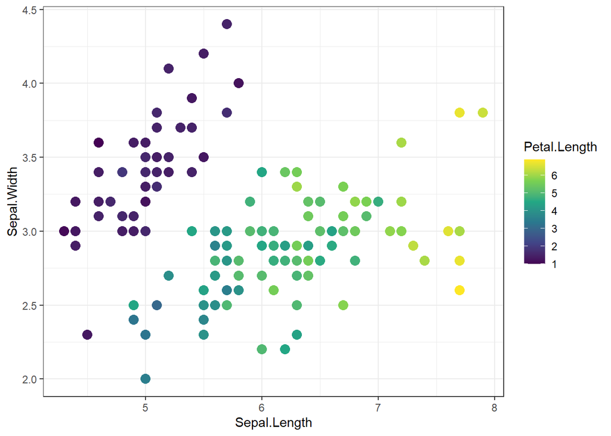

```r
iris %>%
  ggplot(mapping = aes(x = Sepal.Length, y = Sepal.Width)) +
  geom_point(mapping = aes(color = Petal.Length),
             size = 3.5) +
  scale_color_viridis_c() +
  theme_bw()
```

There are multiple viridis options.

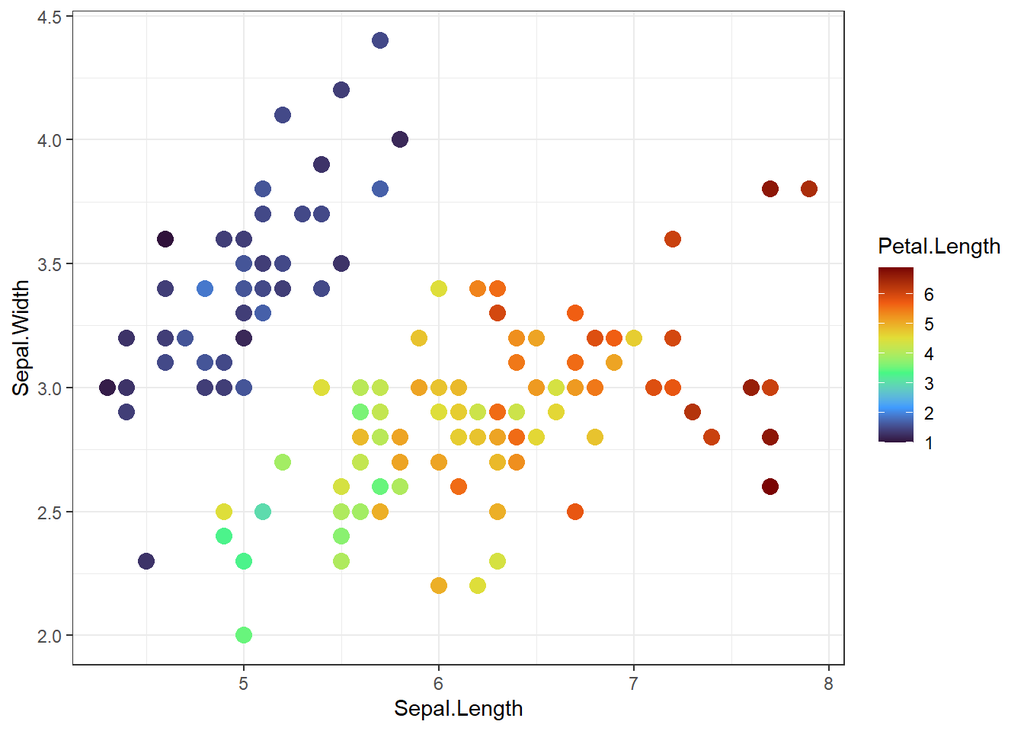

```r
iris %>%
  ggplot(mapping = aes(x = Sepal.Length, y = Sepal.Width)) +
  geom_point(mapping = aes(color = Petal.Length),
             size = 3.5) +
  scale_color_viridis_c(option = 'turbo') +
  theme_bw()
```

We can bin or categorize a continuous variable.

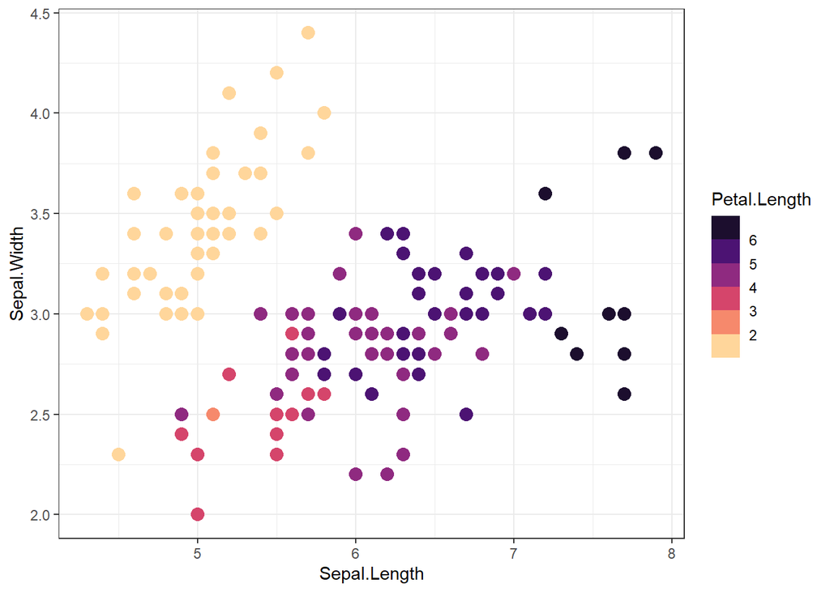

```r
iris %>%
  ggplot(mapping = aes(x = Sepal.Length, y = Sepal.Width)) +
  geom_point(mapping = aes(color = Petal.Length),
             size = 3.5) +
  scale_color_viridis_b(option = 'magma', direction = -1) +
  theme_bw()
```

### 4 variables

We can use shape for categorical combined with color for continuous.

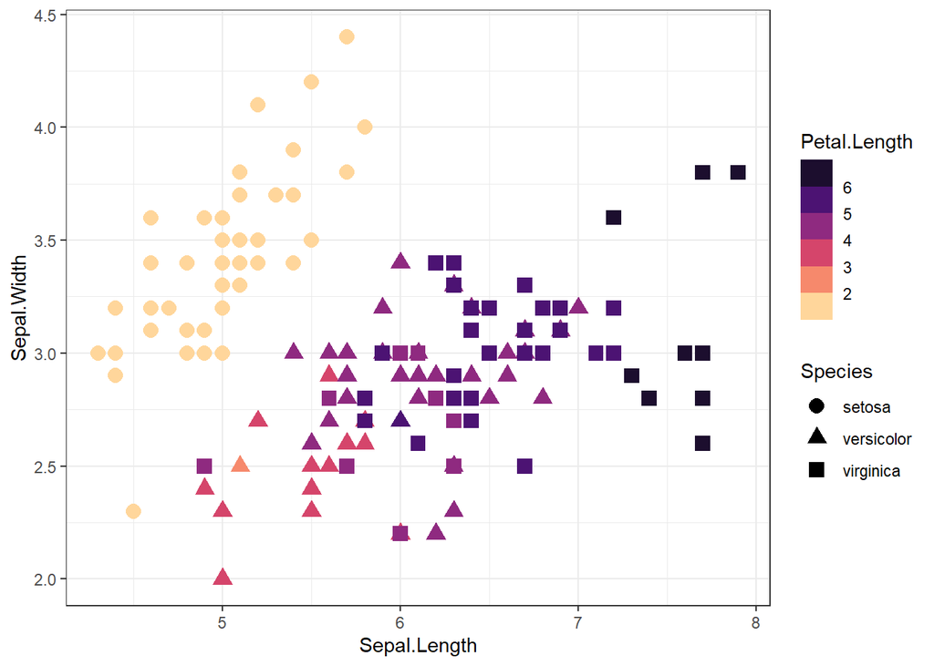

```r
iris %>%
  ggplot(mapping = aes(x = Sepal.Length, y = Sepal.Width)) +
  geom_point(mapping = aes(color = Petal.Length,
                           shape = Species),
             size = 3.5) +
  scale_color_viridis_b(option = 'magma', direction = -1) +
  theme_bw()
```

Alternatively we can use facets for categorical variables.

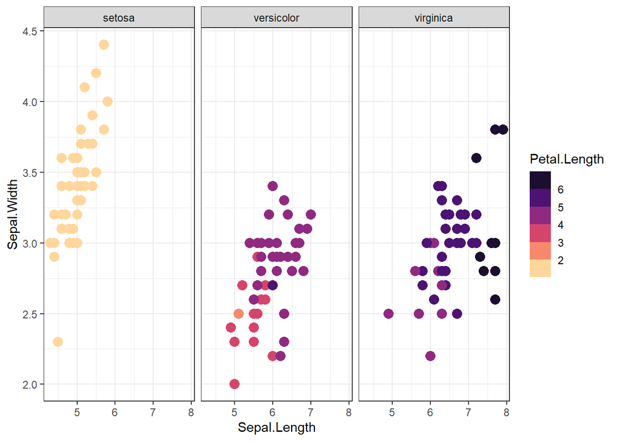

```r
iris %>%
  ggplot(mapping = aes(x = Sepal.Length, y = Sepal.Width)) +
  geom_point(mapping = aes(color = Petal.Length),
             size = 3.5) +
  facet_wrap(~Species) +
  scale_color_viridis_b(option = 'magma', direction = -1) +
  theme_bw()
```

Change the facet strip background.

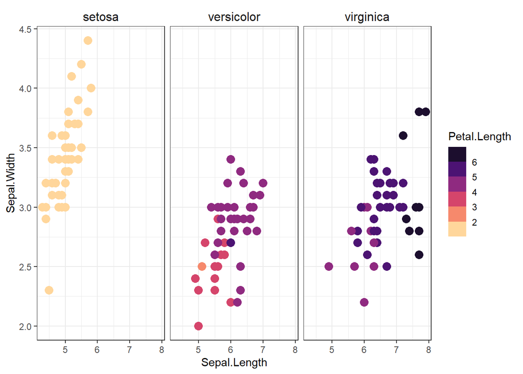

```r
iris %>%
  ggplot(mapping = aes(x = Sepal.Length, y = Sepal.Width)) +
  geom_point(mapping = aes(color = Petal.Length),
             size = 3.5) +
  facet_wrap(~Species) +
  scale_color_viridis_b(option = 'magma', direction = -1) +
  theme_bw() +
  theme(strip.background = element_blank(),
        strip.text = element_text(size = 12))
```

We can also use color for a categorical. In-line define a boolean for petal being larger than the median petal length.

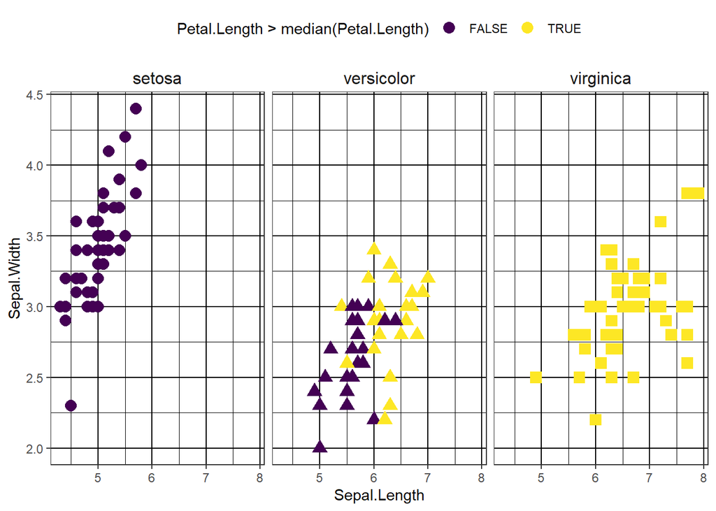

```r
iris %>%
  ggplot(mapping = aes(x = Sepal.Length, y = Sepal.Width)) +
  geom_point(mapping = aes(color = Petal.Length > median(Petal.Length),
                           shape = Species),
             size = 3.5) +
  facet_wrap(~Species) +
  scale_color_viridis_d(option = 'viridis') +
  scale_shape_discrete(guide = 'none') +
  theme_bw() +
  theme(strip.background = element_blank(),
        strip.text = element_text(size = 12),
        legend.position = 'top',
        panel.grid = element_line(color = 'black'))
```

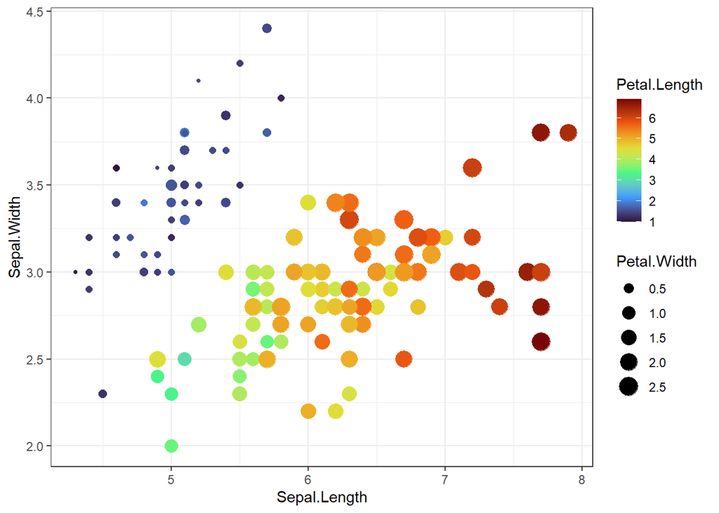

```r
iris %>%
  ggplot(mapping = aes(x = Sepal.Length, y = Sepal.Width)) +
  geom_point(mapping = aes(color = Petal.Length,
                           size = Petal.Width)) +
  scale_color_viridis_c(option = 'turbo') +
  theme_bw()
```

### 5 variables

We can show 4 continuous variables and 1 categorical on a single scatter plot.

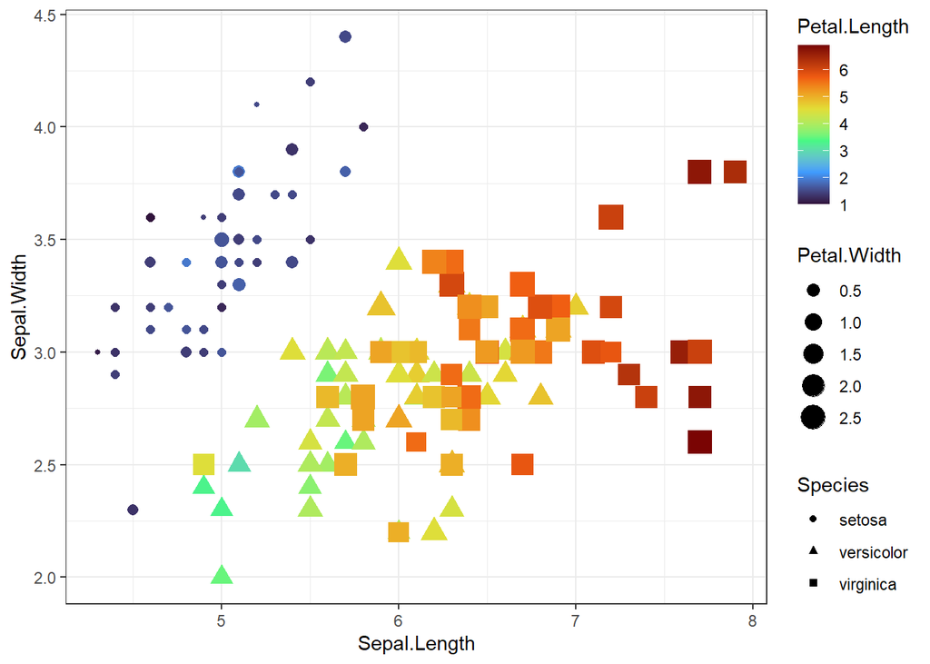

```r
iris %>%
  ggplot(mapping = aes(x = Sepal.Length, y = Sepal.Width)) +
  geom_point(mapping = aes(color = Petal.Length,
                           size = Petal.Width,
                           shape = Species)) +
  scale_color_viridis_c(option = 'turbo') +
  theme_bw()
```

Alternatively we can use facets for the categorical.

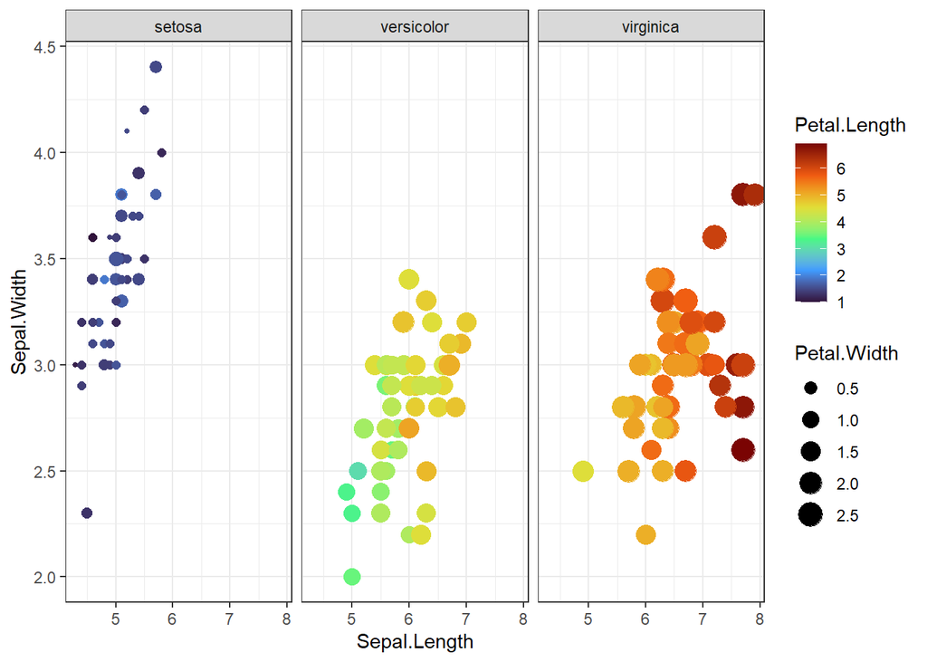

```r
iris %>%
  ggplot(mapping = aes(x = Sepal.Length, y = Sepal.Width)) +
  geom_point(mapping = aes(color = Petal.Length,
                           size = Petal.Width)) +
  facet_wrap(~Species) +
  scale_color_viridis_c(option = 'turbo') +
  theme_bw()
```

But if we look at the petal variables…

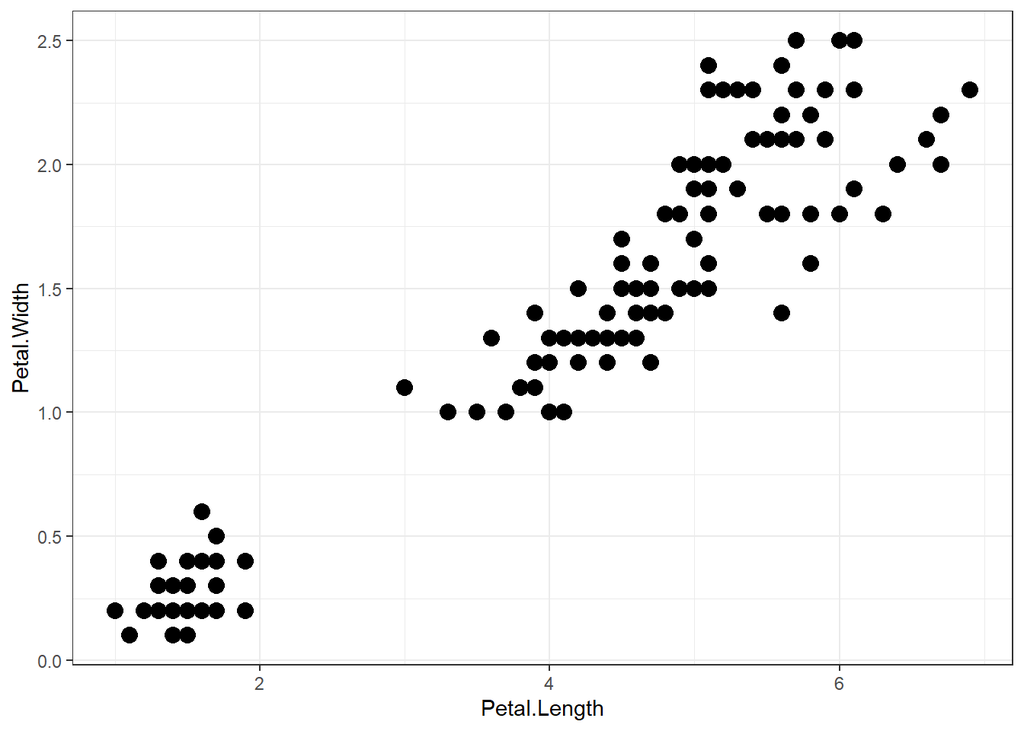

```r
iris %>%
  ggplot(mapping = aes(x = Petal.Length, y = Petal.Width)) +
  geom_point(size = 3.5) +
  theme_bw()
```

## What are looking at with Scatter plots?

We are trying to find **linear relationships** or **correlations** between PAIRS of variables.

Can we get a high level overview of the **correlation** between **ALL** pairs of variables?

To use corrplot we need to calculate the **correlation matrix**.

```r
iris %>%
  purrr::keep(is.numeric) %>%
  cor()
```

```
##              Sepal.Length Sepal.Width Petal.Length Petal.Width
## Sepal.Length    1.0000000  -0.1175698    0.8717538   0.8179411
## Sepal.Width    -0.1175698   1.0000000   -0.4284401  -0.3661259
## Petal.Length    0.8717538  -0.4284401    1.0000000   0.9628654
## Petal.Width     0.8179411  -0.3661259    0.9628654   1.0000000
```

Instead of printing or displaying the correlation plot, let’s visualize it with `corrplot()`.

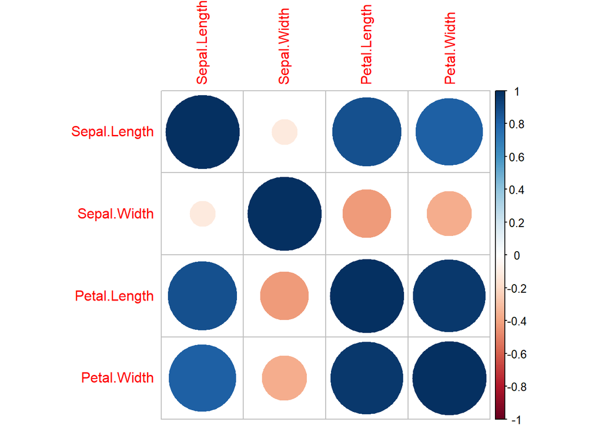

```r
iris %>%
  purrr::keep(is.numeric) %>%
  cor() %>%
  corrplot::corrplot()
```

We can override the default arguments to show just the upper triangular portion.

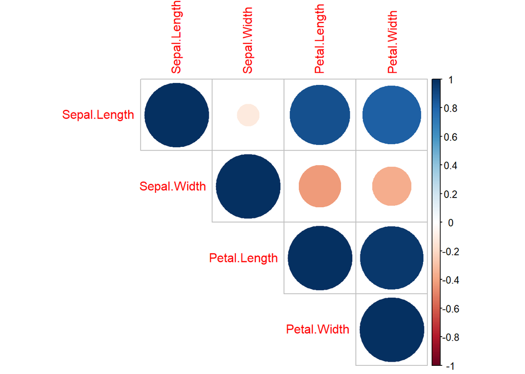

```r
iris %>%
  purrr::keep(is.numeric) %>%
  cor() %>%
  corrplot::corrplot(type = 'upper')
```

We can show numbers instead of circles.

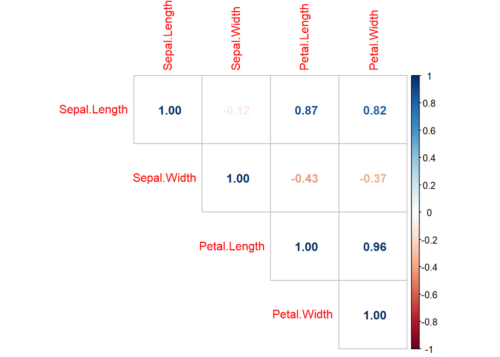

```r
iris %>%
  purrr::keep(is.numeric) %>%
  cor() %>%
  corrplot::corrplot(type = 'upper', method = 'number')
```

Or can use a mixture of circles and numbers.

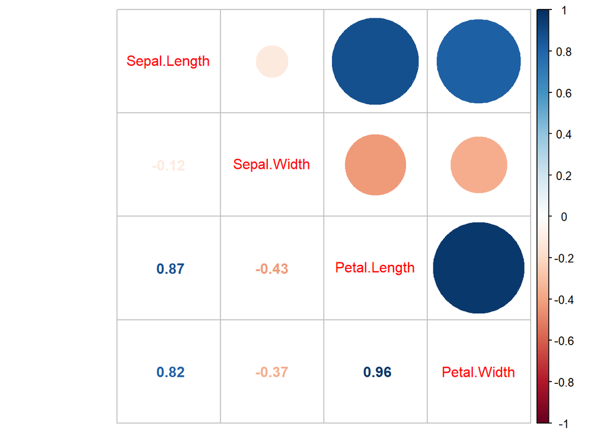

```r
iris %>%
  purrr::keep(is.numeric) %>%
  cor() %>%
  corrplot::corrplot.mixed()
```

We can use other methods such as squares.

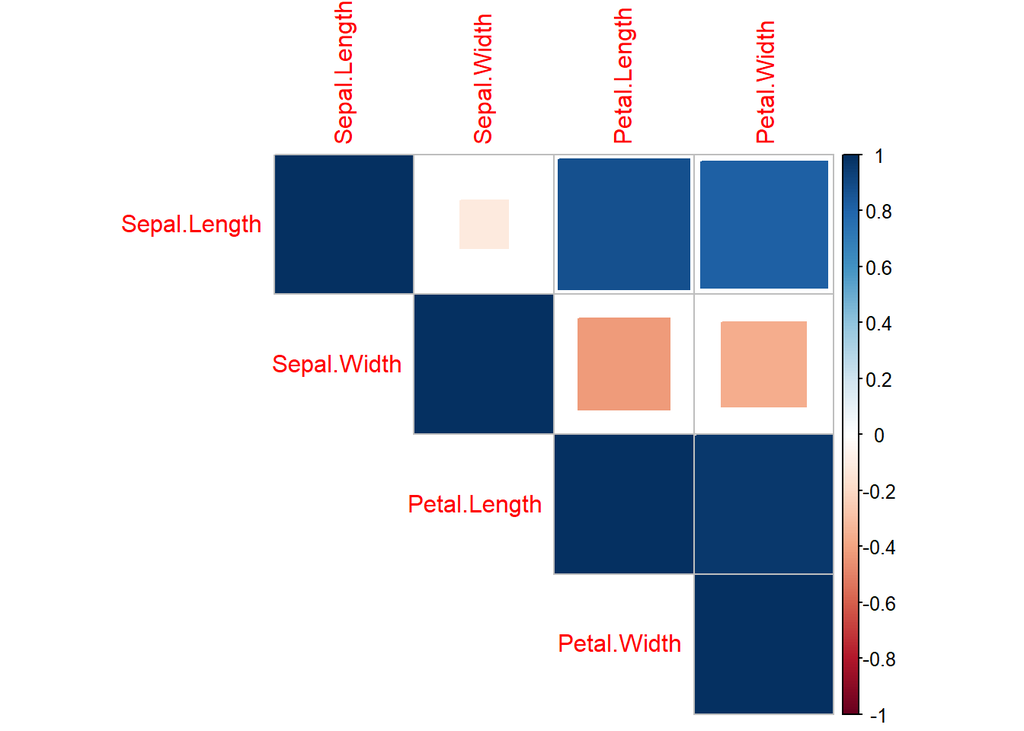

```r
iris %>%
  purrr::keep(is.numeric) %>%
  cor() %>%
  corrplot::corrplot(type = 'upper', method = 'square')
```

The pie chart can be thrown in…

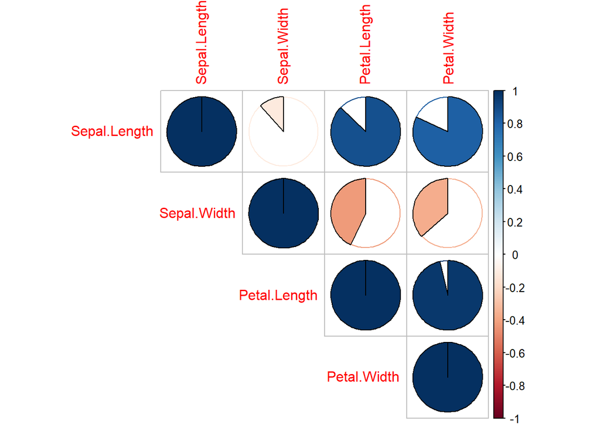

```r
iris %>%
  purrr::keep(is.numeric) %>%
  cor() %>%
  corrplot::corrplot(type = 'upper', method = 'pie')
```

### Tidyverse correlation plots

We will use `corrr`.

```r
library(corrr)
```

```r
iris %>%
  purrr::keep(is.numeric) %>%
  corrr::correlate()
```

```
##
## Correlation method: 'pearson'
## Missing treated using: 'pairwise.complete.obs'
```

```
## # A tibble: 4 × 5
##   term         Sepal.Length Sepal.Width Petal.Length Petal.Width
##   <chr>               <dbl>       <dbl>        <dbl>       <dbl>
## 1 Sepal.Length       NA          -0.118        0.872       0.818
## 2 Sepal.Width        -0.118      NA           -0.428      -0.366
## 3 Petal.Length        0.872      -0.428       NA           0.963
## 4 Petal.Width         0.818      -0.366        0.963      NA
```

I like to include 1’s along the main diagonal.

```r
iris %>%
  purrr::keep(is.numeric) %>%
  corrr::correlate(diagonal = 1, quiet = TRUE)
```

```
## # A tibble: 4 × 5
##   term         Sepal.Length Sepal.Width Petal.Length Petal.Width
##   <chr>               <dbl>       <dbl>        <dbl>       <dbl>
## 1 Sepal.Length        1          -0.118        0.872       0.818
## 2 Sepal.Width        -0.118       1           -0.428      -0.366
## 3 Petal.Length        0.872      -0.428        1           0.963
## 4 Petal.Width         0.818      -0.366        0.963       1
```

The `corrr` package has built in plotting functions dedicated to correlation objects.

```r
iris_corrr <- iris %>%
  purrr::keep(is.numeric) %>%
  corrr::correlate(diagonal = 1, quiet = TRUE)
```

The default plot is created by `rplot()`.

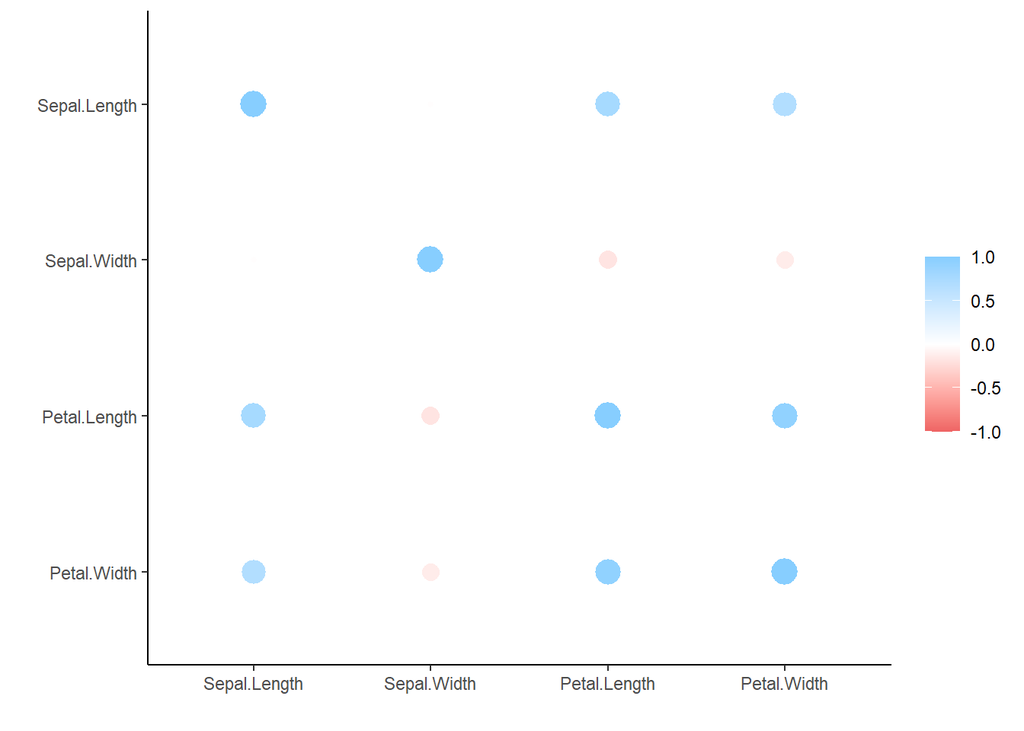

```r
iris_corrr %>% rplot()
```

It also has a slick network diagram to show correlations.

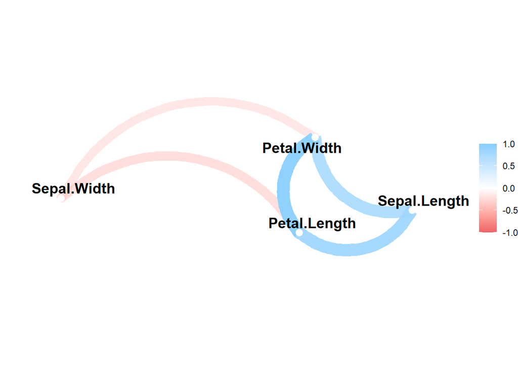

```r
iris_corrr %>% network_plot()
```

So how can we group?

```r
iris_corrr %>%
  corrr::stretch()
```

```
## # A tibble: 16 × 3
##    x            y                 r
##    <chr>        <chr>         <dbl>
##  1 Sepal.Length Sepal.Length  1
##  2 Sepal.Length Sepal.Width  -0.118
##  3 Sepal.Length Petal.Length  0.872
##  4 Sepal.Length Petal.Width   0.818
##  5 Sepal.Width  Sepal.Length -0.118
##  6 Sepal.Width  Sepal.Width   1
##  7 Sepal.Width  Petal.Length -0.428
##  8 Sepal.Width  Petal.Width  -0.366
##  9 Petal.Length Sepal.Length  0.872
## 10 Petal.Length Sepal.Width  -0.428
## 11 Petal.Length Petal.Length  1
## 12 Petal.Length Petal.Width   0.963
## 13 Petal.Width  Sepal.Length  0.818
## 14 Petal.Width  Sepal.Width  -0.366
## 15 Petal.Width  Petal.Length  0.963
## 16 Petal.Width  Petal.Width   1
```

We can now manually create our own correlation plot.

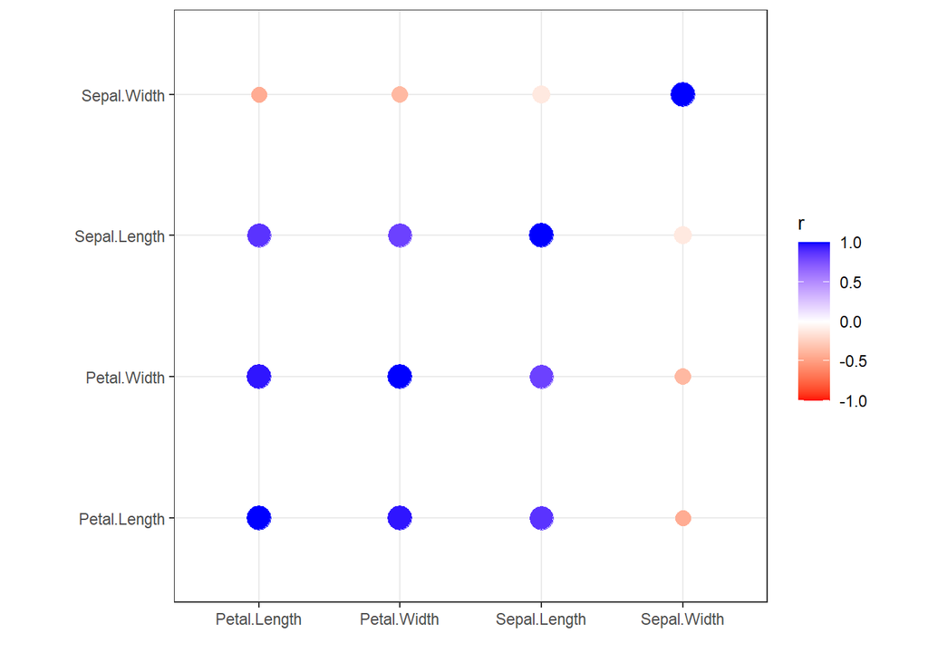

```r
iris_corrr %>%
  corrr::stretch() %>%
  ggplot(mapping = aes(x = x, y = y)) +
  geom_point(mapping = aes(color = r,
                           size = r)) +
  coord_equal() +
  scale_color_gradient2(low = 'red', mid = 'white', high = 'blue',
                        midpoint = 0,
                        limits = c(-1, 1)) +
  scale_size_continuous(guide = 'none',
                        limits = c(-1, 1)) +
  labs(x = '', y ='') +
  theme_bw()
```

To create a grouped object we need to use a grouping operation.

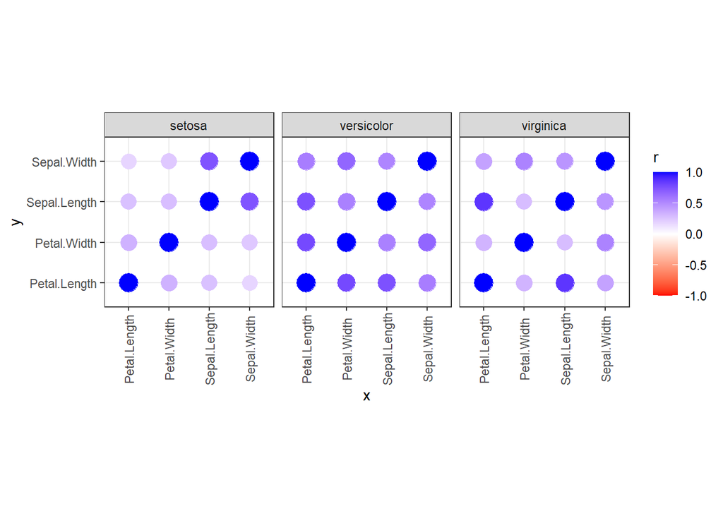

```r
iris %>%
  group_by(Species) %>%
  group_modify( ~stretch( correlate(., diagonal = 1, quiet = TRUE) ) ) %>%
  ungroup() %>%
  ggplot(mapping = aes(x = x, y = y)) +
  geom_point(mapping = aes(color = r,
                           size = r)) +
  coord_equal() +
  facet_wrap(~Species) +
  scale_color_gradient2(low = 'red', mid = 'white', high = 'blue',
                        midpoint = 0,
                        limits = c(-1, 1)) +
  scale_size_continuous(guide = 'none',
                        limits = c(-1, 1)) +
  theme_bw() +
  theme(axis.text.x = element_text(angle = 90, vjust = 0.5))
```